# Predictive Liver Disease

Libraries and packages

```r
library(ggplot2)
library(dplyr)
library(caret)
library(randomForest)
library(car)
library(gridExtra)
library(reshape2)
library(ggcorrplot)
library(pROC)
```

Download the dataset

```r
data <- read.csv("/Users/asus/Desktop/R/Liver_disease_data.csv")
head(data)
```

|  | Age | Gender | BMI | AlcoholConsumption | Smoking | GeneticRisk | PhysicalActivity | Diabetes | Hypertension | LiverFunctionTest | Diagnosis |
| --- | --- | --- | --- | --- | --- | --- | --- | --- | --- | --- | --- |
| 1 | 58 | 0 | 35.85758 | 17.272828 | 0 | 1 | 0.6589402 | 0 | 0 | 42.73424 | 1 |
| 2 | 71 | 1 | 30.73247 | 2.201266 | 0 | 1 | 1.6705567 | 1 | 0 | 67.30982 | 1 |
| 3 | 48 | 0 | 19.97141 | 18.500944 | 0 | 0 | 9.9283083 | 0 | 0 | 63.73896 | 0 |
| 4 | 34 | 1 | 16.61542 | 12.632870 | 0 | 0 | 5.6301294 | 0 | 0 | 64.55587 | 1 |
| 5 | 62 | 1 | 16.06583 | 1.087815 | 0 | 1 | 3.5662180 | 1 | 0 | 77.86869 | 1 |
| 6 | 27 | 1 | 24.28521 | 12.885134 | 0 | 2 | 2.8820269 | 0 | 0 | 50.53506 | 1 |

```r
summary(data)
```

```
      Age            Gender            BMI        AlcoholConsumption     Smoking        GeneticRisk     PhysicalActivity      Diabetes       Hypertension
 Min.   :20.00   Min.   :0.0000   Min.   :15.00   Min.   : 0.003731   Min.   :0.0000   Min.   :0.0000   Min.   :0.001852   Min.   :0.0000   Min.   :0.0000
 1st Qu.:35.00   1st Qu.:0.0000   1st Qu.:21.46   1st Qu.: 4.841811   1st Qu.:0.0000   1st Qu.:0.0000   1st Qu.:2.622121   1st Qu.:0.0000   1st Qu.:0.0000
 Median :51.00   Median :1.0000   Median :27.93   Median : 9.828195   Median :0.0000   Median :0.0000   Median :5.022883   Median :0.0000   Median :0.0000
 Mean   :50.39   Mean   :0.5041   Mean   :27.70   Mean   : 9.832309   Mean   :0.2918   Mean   :0.5218   Mean   :5.000993   Mean   :0.1424   Mean   :0.1547
 3rd Qu.:66.00   3rd Qu.:1.0000   3rd Qu.:33.96   3rd Qu.:14.871671   3rd Qu.:1.0000   3rd Qu.:1.0000   3rd Qu.:7.401642   3rd Qu.:0.0000   3rd Qu.:0.0000
 Max.   :80.00   Max.   :1.0000   Max.   :39.99   Max.   :19.952456   Max.   :1.0000   Max.   :2.0000   Max.   :9.994964   Max.   :1.0000   Max.   :1.0000
 LiverFunctionTest   Diagnosis
 Min.   :20.02     Min.   :0.0000
 1st Qu.:40.02     1st Qu.:0.0000
 Median :59.51     Median :1.0000
 Mean   :59.86     Mean   :0.5506
 3rd Qu.:79.43     3rd Qu.:1.0000
 Max.   :99.99     Max.   :1.0000
```

As seen in the EDA part, the model has some categorical variables which assume values of 0 and 1 (for example female and male). In R, it is important to convert these variables into factors which are a specific type of data design to handle categorical data.

```r
data$Diagnosis <- as.factor(data$Diagnosis)
data$Gender <- as.factor(data$Gender)
data$Smoking <- as.factor(data$Smoking)
data$Diabetes <- as.factor(data$Diabetes)
data$Hypertension <- as.factor(data$Hypertension)
```

To prevent over fitting and make sure the model generalizes well to unseen data, we are going to divide the data into test and training.

```r
set.seed(123) # generate reproducible psudorandom numbers
trainIndex <- createDataPartition(data$Diagnosis, p = 0.7, list = FALSE) # divide 70% data to train and 30% to test
train_data <- data[trainIndex, ]
test_data <- data[-trainIndex, ]
```

There are many combinations of variables possible of choosing to perform a logistic regression. It is impossible to test all combination in order to see which is the best model for the prediction of the liver disease. So, in this work we perform two methods to see which can be the best combination of variables: the first is do the stepwise method, which is done in another notebook. The second is to do a literature review about this and understand which might be an interesting combination of variables. For that we allow the user to choose the variables and try and see the performance of that model.

First, let’s see which are the variables available for the modelling

```r
cat("Available variables for modeling:\n")
```

```
Available variables for modeling:
```

```r
all_vars <- colnames(train_data)
all_vars <- all_vars[all_vars != "Diagnosis"] # exclude the clas
print(all_vars)
```

```
 [1] "Age"                "Gender"             "BMI"                "AlcoholConsumption" "Smoking"            "GeneticRisk"        "PhysicalActivity"
 [8] "Diabetes"           "Hypertension"       "LiverFunctionTest"
```

Second, we select the variables we want to put in our model

```r
selected_vars <- c("Age", "BMI", "LiverFunctionTest")  # SPECIFY VARIABLES HERE
selected_formula <- paste("Diagnosis ~", paste(selected_vars, collapse = " + "))

# Print the selected formula
cat("\nUsing the following formula for the model:", selected_formula, "\n")
```

```
Using the following formula for the model: Diagnosis ~ Age + BMI + LiverFunctionTest
```

Train the logistic regression model given that our class Diagnostic is the dependent variable and the other variables are independent and that the outcome is binary.

```r
model <- glm(as.formula(selected_formula), data = train_data, family = binomial)
summary(model)
```

```
Call:
glm(formula = as.formula(selected_formula), family = binomial,
    data = train_data)

Coefficients:
                   Estimate Std. Error z value Pr(>|z|)
(Intercept)       -4.199390   0.380410 -11.039  < 2e-16 ***
Age                0.022207   0.003704   5.995 2.03e-09 ***
BMI                0.043679   0.008989   4.859 1.18e-06 ***
LiverFunctionTest  0.035579   0.002966  11.994  < 2e-16 ***
---
Signif. codes:  0 ‘***’ 0.001 ‘**’ 0.01 ‘*’ 0.05 ‘.’ 0.1 ‘ ’ 1

(Dispersion parameter for binomial family taken to be 1)

    Null deviance: 1638.8  on 1190  degrees of freedom
Residual deviance: 1414.2  on 1187  degrees of freedom
AIC: 1422.2

Number of Fisher Scoring iterations: 4
```

Make predictions with the test data

```r
pred_probs <- predict(model, newdata = test_data, type = "response")

# Convert probabilities to class labels (0 or 1)
pred_class <- ifelse(pred_probs > 0.5, 1, 0)
```

Confusion matrix to evaluate results

```r
conf_matrix <- table(Predicted = pred_class, Actual = test_data$Diagnosis)
print(conf_matrix)
```

```
         Actual
Predicted   0   1
        0 134  71
        1  95 209
```

Some evaluation metrics of the model

```r
accuracy <- sum(diag(conf_matrix)) / sum(conf_matrix)
print(paste("Accuracy: ", round(accuracy * 100, 2), "%"))
```

```
[1] "Accuracy:  67.39 %"
```

```r
precision <- conf_matrix[2, 2] / sum(conf_matrix[2, ])
recall <- conf_matrix[2, 2] / sum(conf_matrix[, 2])
f1_score <- 2 * (precision * recall) / (precision + recall)

print(paste("Precision: ", precision))
```

```
[1] "Precision:  0.6875"
```

```r
print(paste("Recall: ", recall))
```

```
[1] "Recall:  0.746428571428571"
```

```r
print(paste("F1 Score: ", f1_score))
```

```
[1] "F1 Score:  0.715753424657534"
```

ROC curve: graphical representation of a classification model’s performance across different classification thresholds. Demonstrates the trade-off between sensitivity (true positive rate) and specificity (1 - false positive rate). And the AUC value, which summarizes the overall performance in a number that ranges between 0 and 1, where the closer to 1, the best.

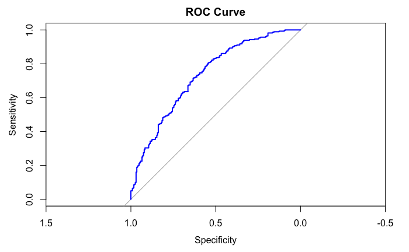

```r
roc_curve <- roc(test_data$Diagnosis, pred_probs)
plot(roc_curve, col = "blue", main = "ROC Curve")
```

```r
auc_value <- auc(roc_curve)
print(paste("AUC: ", auc_value))
```

```
[1] "AUC:  0.731877729257642"
```

Cook’s distance: metric used in regression analysis to measure the influence of each data point on the estimated regression coefficients. It helps identify outliers or influential points that have a disproportionate effect on the fitted model. With the influencial points we can check if these are due to errors or natural variability or apply transformations to mitigate the influence of extreme values

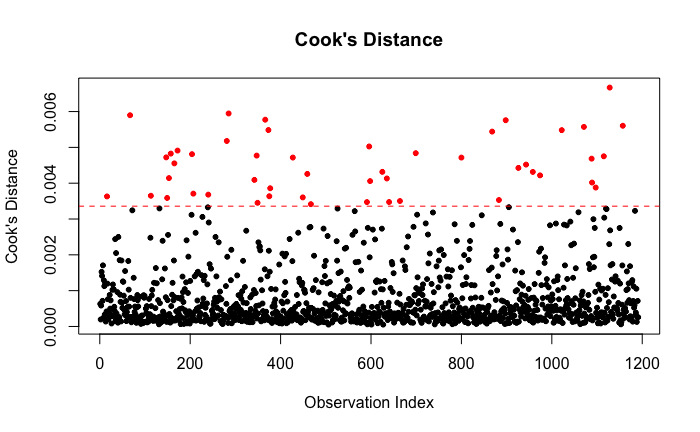

```r
cooks_distance <- cooks.distance(model)

# Plot Cook's Distance
plot(cooks_distance,
     main = "Cook's Distance",
     ylab = "Cook's Distance",
     xlab = "Observation Index",
     pch = 20,
     col = ifelse(cooks_distance > (4 / nrow(train_data)), "red", "black"))
abline(h = 4 / nrow(train_data), col = "red", lty = 2)
```

```r
# Highlight influential points
influential_points <- which(cooks_distance > (4 / nrow(train_data)))
print(paste("Influential points:", paste(influential_points, collapse = ", ")))
```

```
[1] "Influential points: 16, 67, 113, 147, 149, 153, 157, 165, 172, 204, 207, 240, 281, 285, 342, 347, 349, 366, 373, 375, 377, 427, 449, 459, 467, 591, 596, 598, 625, 635, 640, 664, 699, 800, 868, 883, 898, 926, 943, 958, 974, 1022, 1071, 1088, 1089, 1097, 1115, 1128, 1157"
```

For example in this case, we can see that the black points are not highly influential for the model and the red dots are considered influential points because their cook’s distance is greater than the treshold. These are the points that might be disproportionately affecting the regression results. It is important to understand if these points are outliers our truly valid however extreme points of the data.

Now, let’s built some different models given the literature review.

Starting with a model build more of environmental variables, related only with lifestyle, with no genetic influence what so ever:

```r
selected_vars <- c("PhysicalActivity", "AlcoholConsumption", "Smoking")  # SPECIFY VARIABLES HERE
selected_formula <- paste("Diagnosis ~", paste(selected_vars, collapse = " + "))

# Print the selected formula
cat("\nUsing the following formula for the model:", selected_formula, "\n")
```

```
Using the following formula for the model: Diagnosis ~ PhysicalActivity + AlcoholConsumption + Smoking
```

```r
model <- glm(as.formula(selected_formula), data = train_data, family = binomial)
summary(model)
```

```
Call:
glm(formula = as.formula(selected_formula), family = binomial,
    data = train_data)

Coefficients:
                   Estimate Std. Error z value Pr(>|z|)
(Intercept)        -0.89151    0.17743  -5.025 5.05e-07 ***
PhysicalActivity   -0.09583    0.02267  -4.227 2.37e-05 ***
AlcoholConsumption  0.13752    0.01180  11.655  < 2e-16 ***
Smoking1            0.98009    0.14752   6.644 3.06e-11 ***
---
Signif. codes:  0 ‘***’ 0.001 ‘**’ 0.01 ‘*’ 0.05 ‘.’ 0.1 ‘ ’ 1

(Dispersion parameter for binomial family taken to be 1)

    Null deviance: 1638.8  on 1190  degrees of freedom
Residual deviance: 1421.9  on 1187  degrees of freedom
AIC: 1429.9

Number of Fisher Scoring iterations: 4
```

```r
pred_probs <- predict(model, newdata = test_data, type = "response")

# Convert probabilities to class labels (0 or 1)
pred_class <- ifelse(pred_probs > 0.5, 1, 0)
```

```r
conf_matrix <- table(Predicted = pred_class, Actual = test_data$Diagnosis)
print(conf_matrix)
```

```
         Actual
Predicted   0   1
        0 135  55
        1  94 225
```

```r
accuracy <- sum(diag(conf_matrix)) / sum(conf_matrix)
print(paste("Accuracy: ", round(accuracy * 100, 2), "%"))
```

```
[1] "Accuracy:  70.73 %"
```

```r
precision <- conf_matrix[2, 2] / sum(conf_matrix[2, ])
recall <- conf_matrix[2, 2] / sum(conf_matrix[, 2])
f1_score <- 2 * (precision * recall) / (precision + recall)

print(paste("Precision: ", precision))
```

```
[1] "Precision:  0.705329153605016"
```

```r
print(paste("Recall: ", recall))
```

```
[1] "Recall:  0.803571428571429"
```

```r
print(paste("F1 Score: ", f1_score))
```

```
[1] "F1 Score:  0.751252086811352"
```

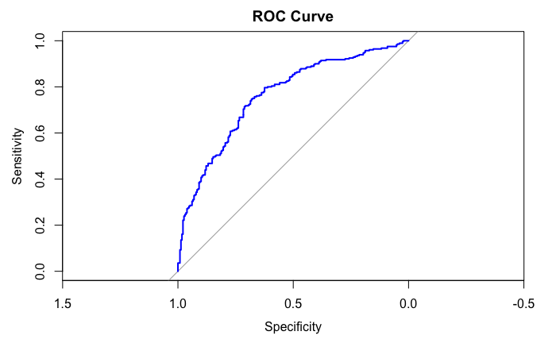

```r
roc_curve <- roc(test_data$Diagnosis, pred_probs)
plot(roc_curve, col = "blue", main = "ROC Curve")
```

```r
auc_value <- auc(roc_curve)
print(paste("AUC: ", auc_value))
```

```
[1] "AUC:  0.760667498440425"
```

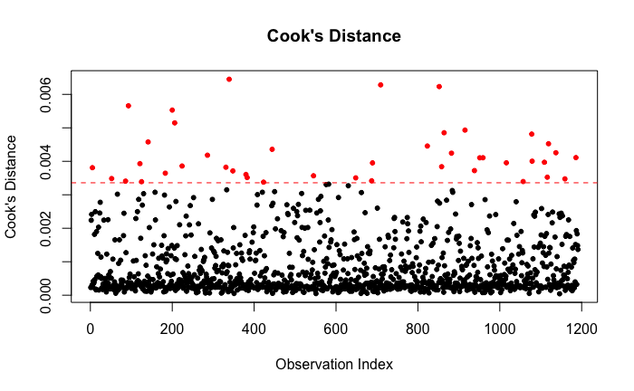

```r
cooks_distance <- cooks.distance(model)

# Plot Cook's Distance
plot(cooks_distance,
     main = "Cook's Distance",
     ylab = "Cook's Distance",
     xlab = "Observation Index",
     pch = 20,
     col = ifelse(cooks_distance > (4 / nrow(train_data)), "red", "black"))
abline(h = 4 / nrow(train_data), col = "red", lty = 2)
```

```r
# Highlight influential points
influential_points <- which(cooks_distance > (4 / nrow(train_data)))
print(paste("Influential points:", paste(influential_points, collapse = ", ")))
```

```
[1] "Influential points: 5, 52, 86, 93, 121, 125, 141, 183, 200, 206, 224, 286, 331, 339, 348, 380, 383, 423, 444, 545, 648, 687, 689, 709, 823, 852, 858, 864, 882, 915, 938, 951, 959, 1016, 1057, 1078, 1079, 1109, 1116, 1119, 1137, 1159, 1186"
```

As expected, the lifestyle is highly influential in predicting Liver disease. It might not be the best model but it still has good results considering it is only considering lifestyle.

Now, let’s built a model with only variables we can not control at all.

```r
selected_vars <- c("Age", "Gender", "GeneticRisk")  # SPECIFY VARIABLES HERE
selected_formula <- paste("Diagnosis ~", paste(selected_vars, collapse = " + "))

# Print the selected formula
cat("\nUsing the following formula for the model:", selected_formula, "\n")
```

```
Using the following formula for the model: Diagnosis ~ Age + Gender + GeneticRisk
```

```r
model <- glm(as.formula(selected_formula), data = train_data, family = binomial)
summary(model)
```

```
Call:
glm(formula = as.formula(selected_formula), family = binomial,
    data = train_data)

Coefficients:
             Estimate Std. Error z value Pr(>|z|)
(Intercept) -1.438998   0.205814  -6.992 2.71e-12 ***
Age          0.020192   0.003524   5.731 1.00e-08 ***
Gender1      0.754768   0.121751   6.199 5.67e-10 ***
GeneticRisk  0.486102   0.094039   5.169 2.35e-07 ***
---
Signif. codes:  0 ‘***’ 0.001 ‘**’ 0.01 ‘*’ 0.05 ‘.’ 0.1 ‘ ’ 1

(Dispersion parameter for binomial family taken to be 1)

    Null deviance: 1638.8  on 1190  degrees of freedom
Residual deviance: 1538.4  on 1187  degrees of freedom
AIC: 1546.4

Number of Fisher Scoring iterations: 4
```

```r
pred_probs <- predict(model, newdata = test_data, type = "response")

# Convert probabilities to class labels (0 or 1)
pred_class <- ifelse(pred_probs > 0.5, 1, 0)
```

```r
conf_matrix <- table(Predicted = pred_class, Actual = test_data$Diagnosis)
print(conf_matrix)
```

```
         Actual
Predicted   0   1
        0 116  90
        1 113 190
```

```r
accuracy <- sum(diag(conf_matrix)) / sum(conf_matrix)
print(paste("Accuracy: ", round(accuracy * 100, 2), "%"))
```

```
[1] "Accuracy:  60.12 %"
```

```r
precision <- conf_matrix[2, 2] / sum(conf_matrix[2, ])
recall <- conf_matrix[2, 2] / sum(conf_matrix[, 2])
f1_score <- 2 * (precision * recall) / (precision + recall)

print(paste("Precision: ", precision))
```

```
[1] "Precision:  0.627062706270627"
```

```r
print(paste("Recall: ", recall))
```

```
[1] "Recall:  0.678571428571429"
```

```r
print(paste("F1 Score: ", f1_score))
```

```
[1] "F1 Score:  0.65180102915952"
```

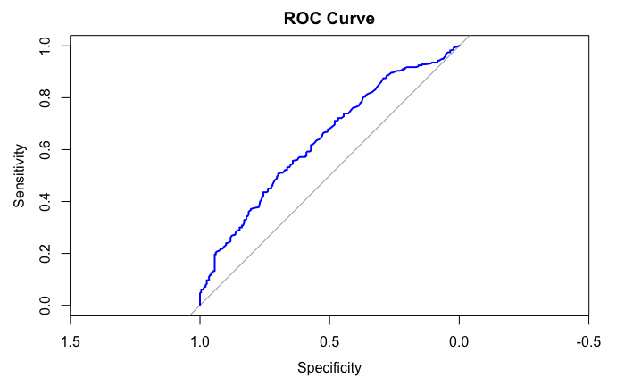

```r
roc_curve <- roc(test_data$Diagnosis, pred_probs)
plot(roc_curve, col = "blue", main = "ROC Curve")
```

```r
auc_value <- auc(roc_curve)
print(paste("AUC: ", auc_value))
```

```
[1] "AUC:  0.636431690580162"
```

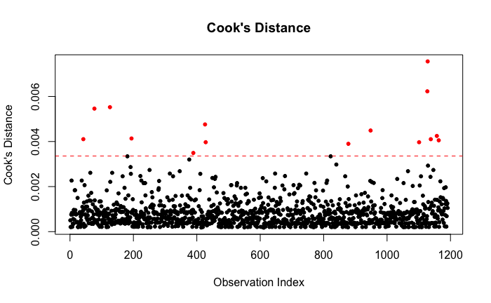

```r
cooks_distance <- cooks.distance(model)

# Plot Cook's Distance
plot(cooks_distance,
     main = "Cook's Distance",
     ylab = "Cook's Distance",
     xlab = "Observation Index",
     pch = 20,
     col = ifelse(cooks_distance > (4 / nrow(train_data)), "red", "black"))
abline(h = 4 / nrow(train_data), col = "red", lty = 2)
```

```r
# Highlight influential points
influential_points <- which(cooks_distance > (4 / nrow(train_data)))
print(paste("Influential points:", paste(influential_points, collapse = ", ")))
```

```
[1] "Influential points: 42, 77, 126, 194, 389, 426, 428, 878, 948, 1101, 1127, 1128, 1138, 1157, 1163"
```

The results are less good considering only these variables. However, it still makes some considerable predictions. And in here is important to note that there are less red dots in the cook’s distance. These metrics are very straight forward and less prone to errors and we can see that in here.

Now, we are building a model considering some more variables, with some genetic component but also a bit environmental

```r
selected_vars <- c("BMI", "Diabetes", "Hypertension")  # SPECIFY VARIABLES HERE
selected_formula <- paste("Diagnosis ~", paste(selected_vars, collapse = " + "))

# Print the selected formula
cat("\nUsing the following formula for the model:", selected_formula, "\n")
```

```
Using the following formula for the model: Diagnosis ~ BMI + Diabetes + Hypertension
```

```r
model <- glm(as.formula(selected_formula), data = train_data, family = binomial)
summary(model)
```

```
Call:
glm(formula = as.formula(selected_formula), family = binomial,
    data = train_data)

Coefficients:
               Estimate Std. Error z value Pr(>|z|)
(Intercept)   -1.214595   0.242887  -5.001 5.71e-07 ***
BMI            0.043374   0.008429   5.146 2.66e-07 ***
Diabetes1      0.506893   0.177989   2.848   0.0044 **
Hypertension1  1.076169   0.183492   5.865 4.49e-09 ***
---
Signif. codes:  0 ‘***’ 0.001 ‘**’ 0.01 ‘*’ 0.05 ‘.’ 0.1 ‘ ’ 1

(Dispersion parameter for binomial family taken to be 1)

    Null deviance: 1638.8  on 1190  degrees of freedom
Residual deviance: 1563.8  on 1187  degrees of freedom
AIC: 1571.8

Number of Fisher Scoring iterations: 4
```

```r
pred_probs <- predict(model, newdata = test_data, type = "response")

# Convert probabilities to class labels (0 or 1)
pred_class <- ifelse(pred_probs > 0.5, 1, 0)
```

```r
conf_matrix <- table(Predicted = pred_class, Actual = test_data$Diagnosis)
print(conf_matrix)
```

```
         Actual
Predicted   0   1
        0 119  67
        1 110 213
```

```r
accuracy <- sum(diag(conf_matrix)) / sum(conf_matrix)
print(paste("Accuracy: ", round(accuracy * 100, 2), "%"))
```

```
[1] "Accuracy:  65.23 %"
```

```r
precision <- conf_matrix[2, 2] / sum(conf_matrix[2, ])
recall <- conf_matrix[2, 2] / sum(conf_matrix[, 2])
f1_score <- 2 * (precision * recall) / (precision + recall)

print(paste("Precision: ", precision))
```

```
[1] "Precision:  0.659442724458204"
```

```r
print(paste("Recall: ", recall))
```

```
[1] "Recall:  0.760714285714286"
```

```r
print(paste("F1 Score: ", f1_score))
```

```
[1] "F1 Score:  0.706467661691542"
```

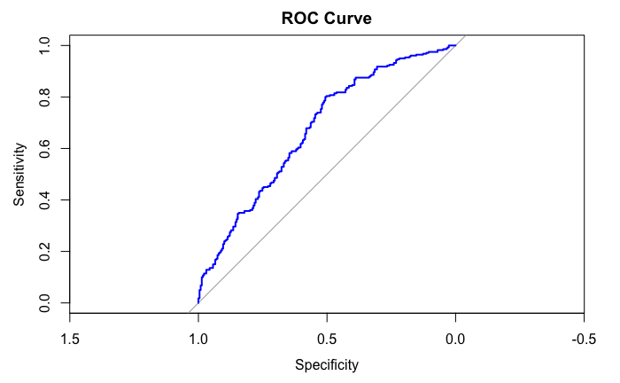

```r
roc_curve <- roc(test_data$Diagnosis, pred_probs)
plot(roc_curve, col = "blue", main = "ROC Curve")
```

```r
auc_value <- auc(roc_curve)
print(paste("AUC: ", auc_value))
```

```
[1] "AUC:  0.672988147223956"
```

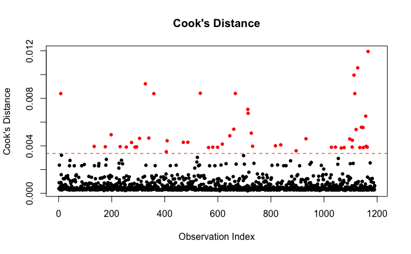

```r
cooks_distance <- cooks.distance(model)

# Plot Cook's Distance
plot(cooks_distance,
     main = "Cook's Distance",
     ylab = "Cook's Distance",
     xlab = "Observation Index",
     pch = 20,
     col = ifelse(cooks_distance > (4 / nrow(train_data)), "red", "black"))
abline(h = 4 / nrow(train_data), col = "red", lty = 2)
```

```r
# Highlight influential points
influential_points <- which(cooks_distance > (4 / nrow(train_data)))
print(paste("Influential points:", paste(influential_points, collapse = ", ")))
```

[output not shown]

These variables, that can have some genetic component but definitly also affected by lifestyle, have the results in the middle of the previous tests: worst than the model only by lifestyle variables but better than the model with only genetic variables. So, we are going to start mixing these, because obviously the liver disease is a complex disease that envolves both contributions: genetic and lifestyle

```r
selected_vars <- c("Age", "Gender", "GeneticRisk", "AlcoholConsumption", "PhysicalActivity" )  # SPECIFY VARIABLES HERE
selected_formula <- paste("Diagnosis ~", paste(selected_vars, collapse = " + "))

# Print the selected formula
cat("\nUsing the following formula for the model:", selected_formula, "\n")
```

```
Using the following formula for the model: Diagnosis ~ Age + Gender + GeneticRisk + AlcoholConsumption + PhysicalActivity
```

```r
model <- glm(as.formula(selected_formula), data = train_data, family = binomial)
summary(model)
```

```
Call:
glm(formula = as.formula(selected_formula), family = binomial,
    data = train_data)

Coefficients:
                    Estimate Std. Error z value Pr(>|z|)
(Intercept)        -2.600078   0.291396  -8.923  < 2e-16 ***
Age                 0.022916   0.003851   5.950 2.68e-09 ***
Gender1             0.927665   0.134467   6.899 5.24e-12 ***
GeneticRisk         0.601651   0.103203   5.830 5.55e-09 ***
AlcoholConsumption  0.147376   0.012357  11.926  < 2e-16 ***
PhysicalActivity   -0.106964   0.023600  -4.532 5.83e-06 ***
---
Signif. codes:  0 ‘***’ 0.001 ‘**’ 0.01 ‘*’ 0.05 ‘.’ 0.1 ‘ ’ 1

(Dispersion parameter for binomial family taken to be 1)

    Null deviance: 1638.8  on 1190  degrees of freedom
Residual deviance: 1349.1  on 1185  degrees of freedom
AIC: 1361.1

Number of Fisher Scoring iterations: 4
```

```r
pred_probs <- predict(model, newdata = test_data, type = "response")

# Convert probabilities to class labels (0 or 1)
pred_class <- ifelse(pred_probs > 0.5, 1, 0)
```

```r
conf_matrix <- table(Predicted = pred_class, Actual = test_data$Diagnosis)
print(conf_matrix)
```

```
         Actual
Predicted   0   1
        0 151  71
        1  78 209
```

```r
accuracy <- sum(diag(conf_matrix)) / sum(conf_matrix)
print(paste("Accuracy: ", round(accuracy * 100, 2), "%"))
```

```
[1] "Accuracy:  70.73 %"
```

```r
precision <- conf_matrix[2, 2] / sum(conf_matrix[2, ])
recall <- conf_matrix[2, 2] / sum(conf_matrix[, 2])
f1_score <- 2 * (precision * recall) / (precision + recall)

print(paste("Precision: ", precision))
```

```
[1] "Precision:  0.72822299651568"
```

```r
print(paste("Recall: ", recall))
```

```
[1] "Recall:  0.746428571428571"
```

```r
print(paste("F1 Score: ", f1_score))
```

```
[1] "F1 Score:  0.73721340388007"
```

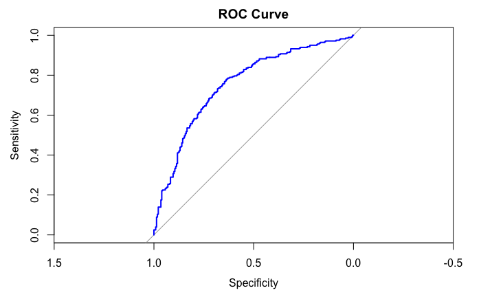

```r
roc_curve <- roc(test_data$Diagnosis, pred_probs)
plot(roc_curve, col = "blue", main = "ROC Curve")
```

```r
auc_value <- auc(roc_curve)
print(paste("AUC: ", auc_value))
```

```
[1] "AUC:  0.755380536494074"
```

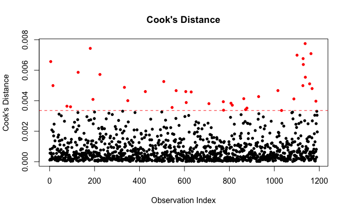

```r
cooks_distance <- cooks.distance(model)

# Plot Cook's Distance
plot(cooks_distance,
     main = "Cook's Distance",
     ylab = "Cook's Distance",
     xlab = "Observation Index",
     pch = 20,
     col = ifelse(cooks_distance > (4 / nrow(train_data)), "red", "black"))
abline(h = 4 / nrow(train_data), col = "red", lty = 2)
```

```r
# Highlight influential points
influential_points <- which(cooks_distance > (4 / nrow(train_data)))
print(paste("Influential points:", paste(influential_points, collapse = ", ")))
```

```
[1] "Influential points: 5, 15, 77, 93, 127, 181, 193, 224, 333, 348, 426, 508, 545, 563, 606, 608, 630, 709, 773, 774, 807, 813, 864, 872, 878, 930, 1016, 1032, 1087, 1101, 1127, 1128, 1129, 1137, 1138, 1157, 1163, 1168, 1185"
```

Now, we perfom one of the last tests with the LiverFunctionTest. This variable is a bit “biased” since it is already an indicator of health of the patient regarding the liver.

```r
selected_vars <- c("Age", "Gender", "GeneticRisk", "AlcoholConsumption", "PhysicalActivity", "LiverFunctionTest")  # SPECIFY VARIABLES HERE
selected_formula <- paste("Diagnosis ~", paste(selected_vars, collapse = " + "))

# Print the selected formula
cat("\nUsing the following formula for the model:", selected_formula, "\n")
```

```
Using the following formula for the model: Diagnosis ~ Age + Gender + GeneticRisk + AlcoholConsumption + PhysicalActivity + LiverFunctionTest
```

```r
model <- glm(as.formula(selected_formula), data = train_data, family = binomial)
summary(model)
```

```
Call:
glm(formula = as.formula(selected_formula), family = binomial,
    data = train_data)

Coefficients:
                    Estimate Std. Error z value Pr(>|z|)
(Intercept)        -6.614499   0.470618 -14.055  < 2e-16 ***
Age                 0.030043   0.004391   6.842 7.79e-12 ***
Gender1             1.232514   0.156268   7.887 3.09e-15 ***
GeneticRisk         0.740960   0.116380   6.367 1.93e-10 ***
AlcoholConsumption  0.202156   0.015347  13.173  < 2e-16 ***
PhysicalActivity   -0.129876   0.026796  -4.847 1.25e-06 ***
LiverFunctionTest   0.051595   0.003790  13.614  < 2e-16 ***
---
Signif. codes:  0 ‘***’ 0.001 ‘**’ 0.01 ‘*’ 0.05 ‘.’ 0.1 ‘ ’ 1

(Dispersion parameter for binomial family taken to be 1)

    Null deviance: 1638.8  on 1190  degrees of freedom
Residual deviance: 1103.3  on 1184  degrees of freedom
AIC: 1117.3

Number of Fisher Scoring iterations: 5
```

```r
pred_probs <- predict(model, newdata = test_data, type = "response")

# Convert probabilities to class labels (0 or 1)
pred_class <- ifelse(pred_probs > 0.5, 1, 0)
```

```r
conf_matrix <- table(Predicted = pred_class, Actual = test_data$Diagnosis)
print(conf_matrix)
```

```
         Actual
Predicted   0   1
        0 167  57
        1  62 223
```

```r
accuracy <- sum(diag(conf_matrix)) / sum(conf_matrix)
print(paste("Accuracy: ", round(accuracy * 100, 2), "%"))
```

```
[1] "Accuracy:  76.62 %"
```

```r
precision <- conf_matrix[2, 2] / sum(conf_matrix[2, ])
recall <- conf_matrix[2, 2] / sum(conf_matrix[, 2])
f1_score <- 2 * (precision * recall) / (precision + recall)

print(paste("Precision: ", precision))
```

```
[1] "Precision:  0.782456140350877"
```

```r
print(paste("Recall: ", recall))
```

```
[1] "Recall:  0.796428571428571"
```

```r
print(paste("F1 Score: ", f1_score))
```

```
[1] "F1 Score:  0.789380530973451"
```

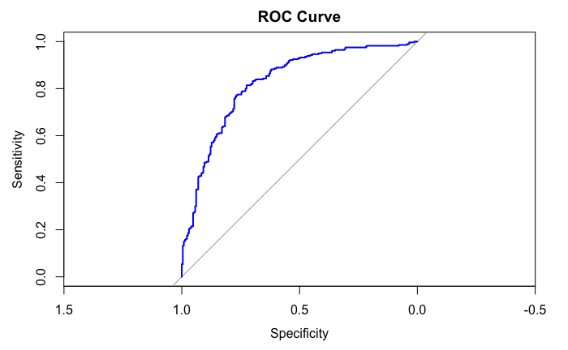

```r
roc_curve <- roc(test_data$Diagnosis, pred_probs)
plot(roc_curve, col = "blue", main = "ROC Curve")
```

```r
auc_value <- auc(roc_curve)
print(paste("AUC: ", auc_value))
```

```
[1] "AUC:  0.825717404865877"
```

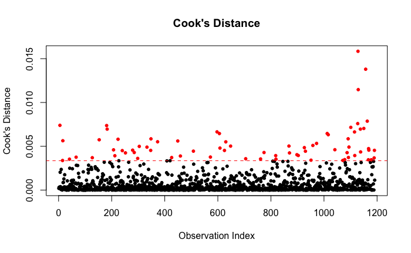

```r
cooks_distance <- cooks.distance(model)

# Plot Cook's Distance
plot(cooks_distance,
     main = "Cook's Distance",
     ylab = "Cook's Distance",
     xlab = "Observation Index",
     pch = 20,
     col = ifelse(cooks_distance > (4 / nrow(train_data)), "red", "black"))
abline(h = 4 / nrow(train_data), col = "red", lty = 2)
```

```r
# Highlight influential points
influential_points <- which(cooks_distance > (4 / nrow(train_data)))
print(paste("Influential points:", paste(influential_points, collapse = ", ")))
```

[output not shown]

As expected, this variable had a lot of effect in the results of the model because it is already a test about this disease.